# Deep learning

Raphael Mourad, Maître de Conférences, Université Paul Sabatier

10/02/2021

## SETUP PROJECT FOLDER

Set up your project folder to your folder “atelier_INSERM”.

```r
knitr::opts_knit$set(root.dir = "/media/raphael/SSD2/atelier_INSERM")
knitr::opts_chunk$set(echo = TRUE)
```

## AIM OF THE SCRIPT

This script is used to train build and train deep learning models for binary classification of positive and negative peak sequences.

## LOAD LIBRARIES

Load R librairies. Remove suppressPackageStartupMessages() for debugging!

```r
suppressPackageStartupMessages(library(GenomicRanges))
suppressPackageStartupMessages(library(Biostrings))
suppressPackageStartupMessages(library(pROC))
suppressPackageStartupMessages(library(tensorflow))
suppressPackageStartupMessages(library(keras))
suppressPackageStartupMessages(library(reticulate))
```

## LOAD FUNCTIONS

```r
suppressPackageStartupMessages(source("scriptR/functions.R"))
```

## SOME PARAMETERS

Define parameters for the analysis:  
- peakSize is the resized peak size. For machine/deep learning, it is easier to work with peaks have the same size.  
- kpeaks is the number of best peaks used. Note that all peaks can also be used.  
- expe is the ChIP-seq experiment. For instance, CTCF for CTCF ChIP-seq or POL2 for RNA Polymerase 2 ChIP-seq experiment.

```r
peakSize=201
kpeaks=4000
expe="DNase"
DNAletters=c("A","C","G","T")
vocab_size=length(DNAletters)
```

## INPUT FILE NAMES

Set file names, which includes:  
- positive peaks from ChIP-seq and negative peaks from the control generator function genNullSeqs().  
- bed (genomic ranges) and fasta files (corresponding DNA sequences).

```r
fileBedPos=paste0("data/bed/",expe,"_GM12878_hg19_",kpeaks,"_pos.bed")
fileBedNeg=paste0("data/bed/",expe,"_GM12878_hg19_",kpeaks,"_neg.bed")
fileFastaPos=paste0("data/fasta/",expe,"_GM12878_hg19_",kpeaks,"_pos.fa")
fileFastaNeg=paste0("data/fasta/",expe,"_GM12878_hg19_",kpeaks,"_neg.fa")
```

## LOAD PROCESSED DATA

Load ChIP-seq and control fasta sequences:

```r
peakPos.seq=readDNAStringSet(fileFastaPos)
peakNeg.seq=readDNAStringSet(fileFastaNeg)
print(peakPos.seq)
```

```
## DNAStringSet object of length 4000:
##        width seq                                            names
##    [1]   201 AATGACCCACCAATCACATGCC...TGTAACACGAGAAAGCACATA chr1_1
##    [2]   201 TCATCACTAGACATCGTACTAC...GTAAATCTAACTTTCTTCCCA chr1_2
##    [3]   201 CCCTATTAGTGGGTGAACAATC...TGAGGCCCCGCTTTCACGGTC chr1_3
##    [4]   201 TTTGCTAGGCAGAATAGTAATG...ATAATTATGCCTCACAGGGAT chr5_4
##    [5]   201 CGGGTCTTCCAGGAGTCGGGTT...CCGCGCAGTCCGCCCGGAGGA chr11_5
##    ...   ... ...
## [3996]   201 AACAGGAAGTCACAGCACTCGA...CATGCATTACTCAGTGTGATA chr6_3996
## [3997]   201 GCGCCCCGCAGGCCCGCCCACT...CGCGAGGCCGGCCTGAGGGAG chr7_3997
## [3998]   201 GCCATTGCCGTCCACCCCGGAA...GTGGGCTAGTCTTCGGACGGC chr7_3998
## [3999]   201 GGACGCACAGGAAGCGAGGGCA...CATTTGAAATGTCTCTATCTG chr7_3999
## [4000]   201 CCTTGCGATTCCCTTCGCCACT...CGCTGATTGGCTGCCGAGACC chr7_4000
```

Bind positive and negative sequences, and make label:

```r
peakAll.seq=c(peakPos.seq,peakNeg.seq)
label=c(rep(1,length(peakPos.seq)),rep(0,length(peakNeg.seq)))
```

Shuffle sequence indices:

```r
idxS=sample(1:length(peakAll.seq))
peakAllS.seq=peakAll.seq[idxS]
labelS=label[idxS]
print(labelS[1:5])
```

```
## [1] 1 1 1 1 1
```

Split train and test indices:

```r
percTrain=0.7
idxTrain=1:(ceiling(length(labelS)*percTrain))
idxTest=(length(idxTrain)+1):length(labelS)
labelTrain=labelS[idxTrain]
labelTest=labelS[idxTest]
```

## DEEP LEARNING METHODS

One hot encoding

```r
oneHotTrain=convertOneHot(peakAllS.seq[idxTrain,])
oneHotTest=convertOneHot(peakAllS.seq[idxTest,])
```

CNN 1 (simple convolution + 10 dense). Simple yet very efficient model.

```r
kernelSize=16
model <- keras_model_sequential()
model %>%
  layer_conv_1d(filters = 128, kernel_size = kernelSize, activation = 'relu',
                input_shape = c(peakSize,vocab_size), name="conv1d_cnn1") %>%
  layer_global_max_pooling_1d() %>%
  layer_dropout(rate = 0.5) %>%
  layer_dense(units = 10, activation = "relu", name="10dense_cnn1") %>%
  layer_dense(units = 1, activation = 'linear', name="2ndlastlayer_cnn1") %>%
  layer_dense(units = 1, activation = 'sigmoid', name="lastlayer_cnn1")
```

CNN 2 (parallel convolution). Useful to model different DNA motif sizes.

```r
if(F){
inputs <- layer_input(shape = c(peakSize-1,vocab_size))
conv1 <- inputs %>%
  layer_conv_1d(filters = 256, kernel_size = 8, activation = 'relu') %>%
  layer_global_max_pooling_1d() %>%
  layer_dropout(rate = 0.5)
conv2 <- inputs %>%
  layer_conv_1d(filters = 256, kernel_size = 16, activation = 'relu') %>%
  layer_global_max_pooling_1d() %>%
  layer_dropout(rate = 0.5)
conv3 <- inputs %>%
  layer_conv_1d(filters = 256, kernel_size = 24, activation = 'relu') %>%
  layer_global_max_pooling_1d() %>%
  layer_dropout(rate = 0.5)
outputs <- layer_concatenate(c(conv1,conv2,conv3)) %>%
  layer_dense(units = 10, activation = "relu") %>%
  layer_dense(units = 1, activation = 'sigmoid')
model <- keras_model(inputs = inputs, outputs = outputs)
}
```

CNN 3 (double convolution + 10 dense). Useful for computer vision, but not for DNA sequences.

```r
if(F){
model <- keras_model_sequential()
model %>%
  layer_conv_1d(filters = 256, kernel_size = 8, activation = 'relu',
                input_shape = c(peakSize-1,vocab_size)) %>%
  layer_conv_1d(filters = 256, kernel_size = 3, activation = 'relu',
                input_shape = c(peakSize-1,vocab_size)) %>%
  layer_global_max_pooling_1d() %>%
  layer_dropout(rate = 0.5) %>%
  layer_dense(units = 10, activation = "relu") %>%
  layer_dense(units = 1, activation = 'sigmoid')
}
```

RNN with LSTM (no CNN). Bad predictions. Bad results. We need to include a convolution layer before the lstm layer! Slow (not made for efficient parallel computing)

```r
if(F){
model <- keras_model_sequential()
model %>%
  layer_lstm(128,input_shape = c(peakSize-1,vocab_size)) %>%
  layer_dropout(rate = 0.5) %>%
  layer_dense(units = 10, activation = "relu") %>%
  layer_dense(1) %>%
  layer_activation("sigmoid")
}
```

CNN + LTSM. Simple yet very efficient model.

```r
if(F){
model <- keras_model_sequential()
model %>%
  layer_conv_1d(filters = 128, kernel_size = 16, activation = 'relu',
                input_shape = c(peakSize-1,vocab_size)) %>%
  layer_dropout(rate = 0.5) %>%
  layer_lstm(12) %>%
  layer_dropout(rate = 0.5) %>%
  layer_dense(units = 20, activation = "relu") %>%
  layer_dense(units = 1, activation = 'sigmoid')
}
```

Model summary

```r
model %>% summary()
```

```
## Model: "sequential"
## ________________________________________________________________________________
## Layer (type)                        Output Shape                    Param #
## ================================================================================
## conv1d_cnn1 (Conv1D)                (None, 186, 128)                8320
## ________________________________________________________________________________
## global_max_pooling1d (GlobalMaxPool (None, 128)                     0
## ________________________________________________________________________________
## dropout (Dropout)                   (None, 128)                     0
## ________________________________________________________________________________
## 10dense_cnn1 (Dense)                (None, 10)                      1290
## ________________________________________________________________________________
## 2ndlastlayer_cnn1 (Dense)           (None, 1)                       11
## ________________________________________________________________________________
## lastlayer_cnn1 (Dense)              (None, 1)                       2
## ================================================================================
## Total params: 9,623
## Trainable params: 9,623
## Non-trainable params: 0
## ________________________________________________________________________________
```

Compile the model SGD and Adagrad = bad results Adam and RMSprop = good results

```r
model %>% compile(
  optimizer = 'rmsprop', # adam or rmsprop are great here
  loss = 'binary_crossentropy',
  metrics = list('accuracy')
)
```

Train the model

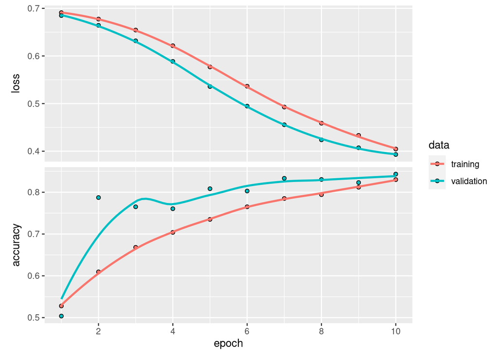

```r
history <- model %>% fit(
  oneHotTrain,
  labelTrain,
  epochs = 10,
  batch_size = 128,
  validation_split = 0.2,
  verbose=1
)
plot(history)
```

Prediction

```r
predCNN=predict(model,oneHotTest)
rocCNN_motif=pROC::roc(as.factor(labelTest),predCNN,ci=T)
```

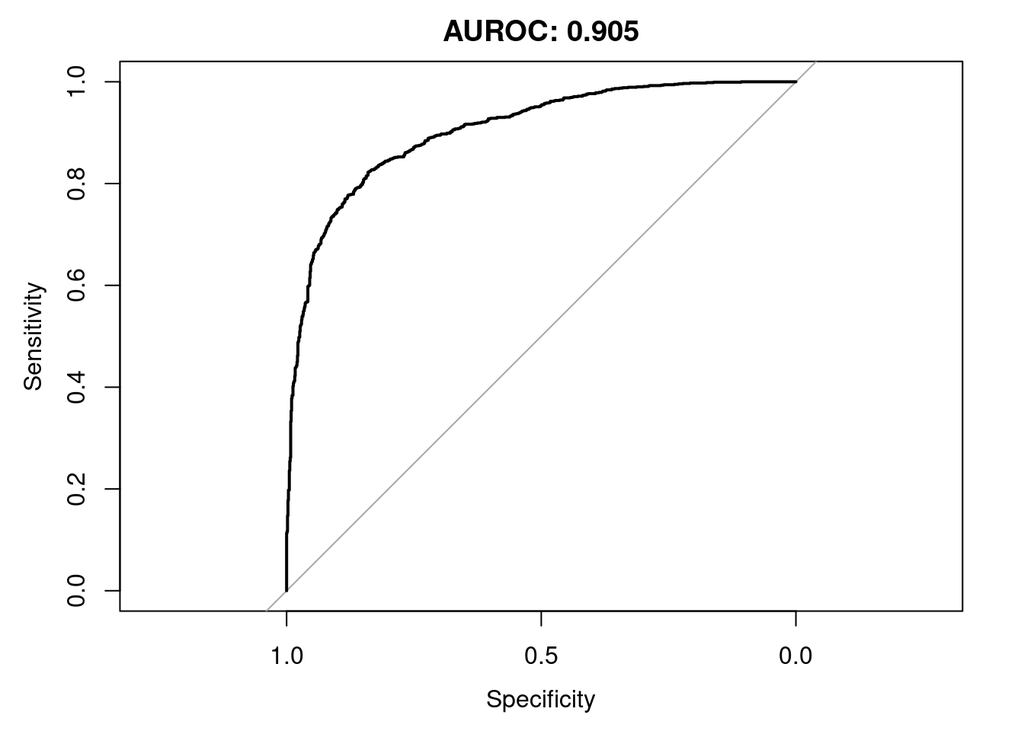

```r
plot(rocCNN_motif,main=paste0("AUROC: ", round(pROC::auc(rocCNN_motif),3)))
```

Accuracy and loss

```r
acc_loss <- model %>% evaluate(oneHotTest, labelTest)
acc_loss
```

```
##      loss  accuracy
## 0.4081141 0.8232258
```

Save model

```r
file_model=paste0("results/model/CNN1_model_",expe,".hdf5")
save_model_hdf5(model,file_model)
```